# Exercise 7.1 Linear Regression

James Hooi

October 25, 2017

## Least squares regression

Use the *states.rds* data set. Fit a model predicting energy consumed per capita (energy) from the percentage of residents living in metropolitan areas (metro).

Check out the base data and plot energy vs metro:

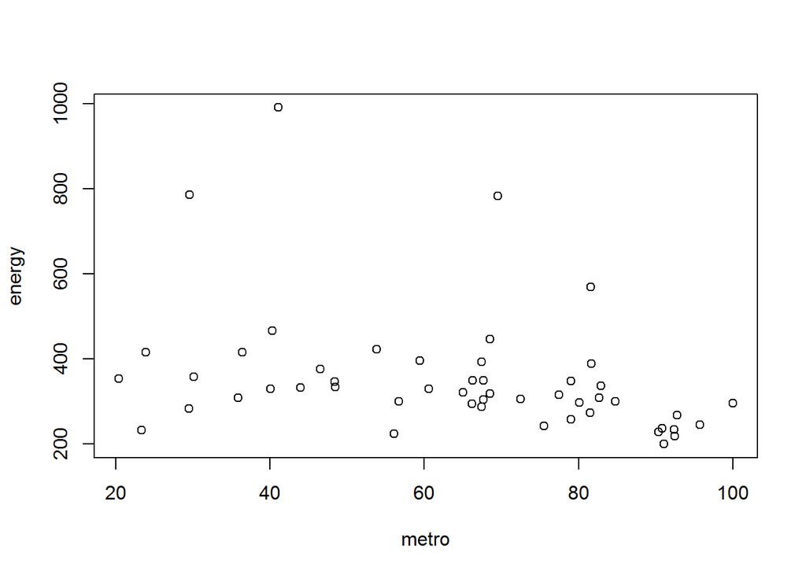

```r
plot(energy ~ metro, data = states.data)
```

Looks like a slightly negative relationship, does a linear regression support this?

```r
energyReg <- lm(energy ~ metro, data = states.data)
summary(energyReg)
```

```
##
## Call:
## lm(formula = energy ~ metro, data = states.data)
##
## Residuals:
##     Min      1Q  Median      3Q     Max
## -215.51  -64.54  -30.87   18.71  583.97
##
## Coefficients:
##             Estimate Std. Error t value Pr(>|t|)
## (Intercept) 501.0292    61.8136   8.105 1.53e-10 ***
## metro        -2.2871     0.9139  -2.503   0.0158 *
## ---
## Signif. codes:  0 '***' 0.001 '**' 0.01 '*' 0.05 '.' 0.1 ' ' 1
##
## Residual standard error: 140.2 on 48 degrees of freedom
##   (1 observation deleted due to missingness)
## Multiple R-squared:  0.1154, Adjusted R-squared:  0.097
## F-statistic: 6.263 on 1 and 48 DF,  p-value: 0.01578
```

The least squares regression supports metro having a slight negative relationship with energy. metro is a significant variable with respect to energy, however the R<sup>2</sup> and adjusted R<sup>2</sup> are both quite low.

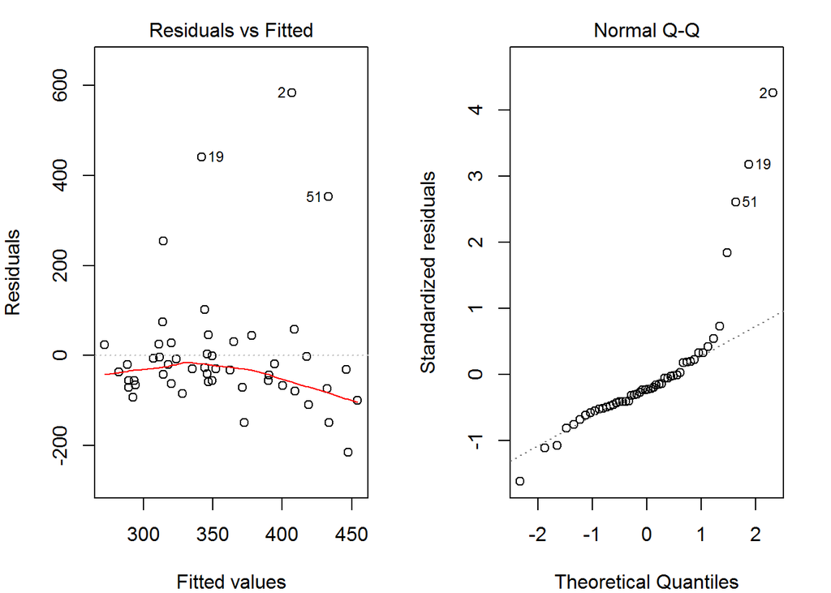

```r
par(mar = c(4, 4, 2, 2), mfrow = c(1, 2))
plot(energyReg, which = c(1, 2))
```

The model becomes a less reliable predictor at higher energy levels, i.e. towards the left of the raw data plot energy v metro. This is expected as the data is sparse here.

### Try adding additional predictor

I added density to the model to see if it improves or degrades.

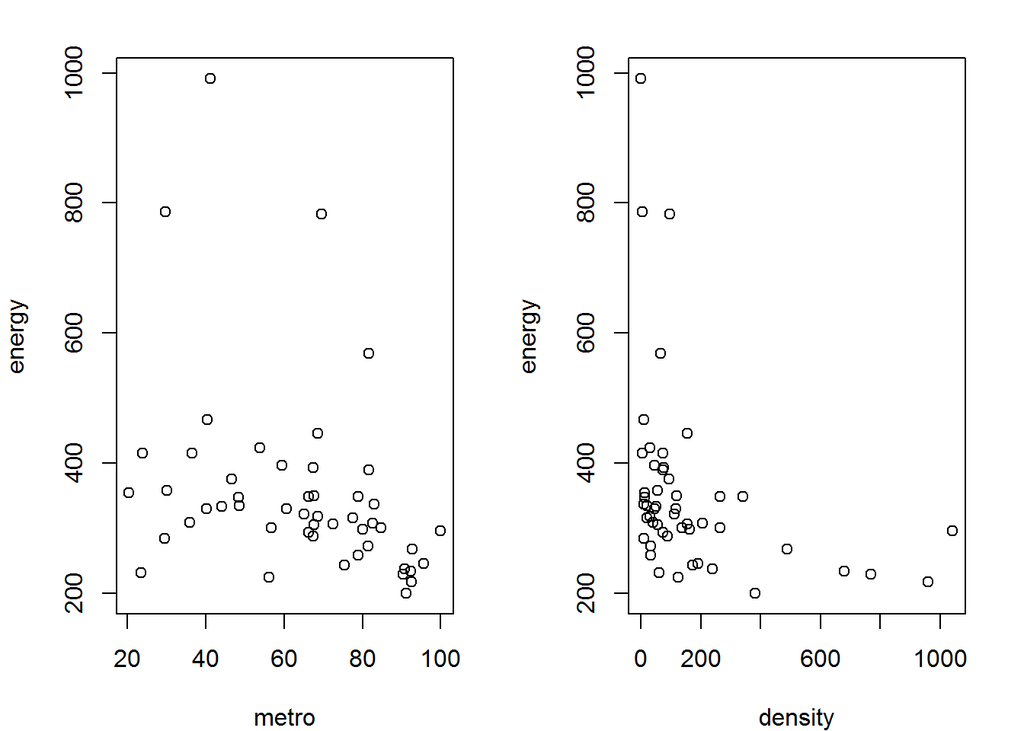

```r
par(mar = c(4, 4, 2, 2), mfrow = c(1, 2))
plot(energy ~ metro, data = states.data)
plot(energy ~ density, data = states.data)
```

Both look like a slightly negative relationship, although the data is clustered around different areas.

```r
energyReg2 <- lm(energy ~ metro + density, data = states.data)
summary(energyReg2)
```

```
##
## Call:
## lm(formula = energy ~ metro + density, data = states.data)
##
## Residuals:
##     Min      1Q  Median      3Q     Max
## -196.38  -68.48  -34.29   16.32  581.87
##
## Coefficients:
##             Estimate Std. Error t value Pr(>|t|)
## (Intercept) 470.9255    66.9316   7.036 7.21e-09 ***
## metro        -1.5008     1.1387  -1.318    0.194
## density      -0.1221     0.1061  -1.151    0.256
## ---
## Signif. codes:  0 '***' 0.001 '**' 0.01 '*' 0.05 '.' 0.1 ' ' 1
##
## Residual standard error: 139.7 on 47 degrees of freedom
##   (1 observation deleted due to missingness)
## Multiple R-squared:  0.1397, Adjusted R-squared:  0.1031
## F-statistic: 3.815 on 2 and 47 DF,  p-value: 0.02916
```

The least squares regression supports both variables having a negative relationship with energy, however neither is significant in spite of the R<sup>2</sup> and adjusted R<sup>2</sup> improving.

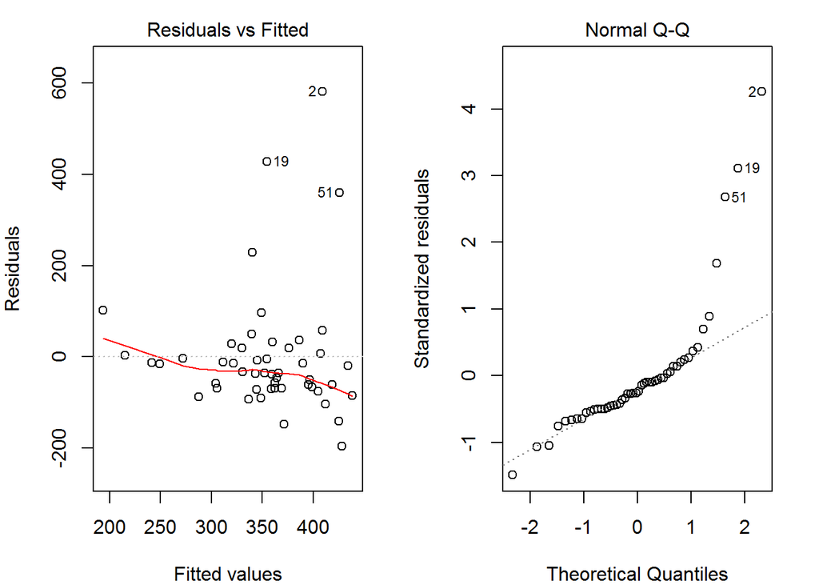

```r
par(mar = c(4, 4, 2, 2), mfrow = c(1, 2))
plot(energyReg2, which = c(1, 2))
```

As before, the model becomes a less reliable predictor at higher energy levels, i.e. towards the left of the raw data plot energy v metro + density.

## Interactions

Tested the interaction between metro and density variables.

```r
energyReg3 <- lm(energy ~ metro*density, data = states.data)
coef(summary(energyReg3))
```

```
##                   Estimate   Std. Error   t value     Pr(>|t|)
## (Intercept)   514.10424265 72.513405133  7.089782 6.683817e-09
## metro          -1.72111951  1.135554671 -1.515664 1.364465e-01
## density        -1.43817898  0.911292059 -1.578176 1.213782e-01
## metro:density   0.01386147  0.009534258  1.453859 1.527747e-01
```

The slope between the two variables is close to zero so they have a minimal impact on each other.

Looking at regions, it does appear there are significant differences in the relationship between energy and metro given each region. While all have a negative relationship, the slopes of the lines are quite different (as shown in the following plot).

```r
coef(summary(lm(energy ~ metro + region, data = states.data)))
```

```
##                  Estimate Std. Error   t value     Pr(>|t|)
## (Intercept)    524.065363 68.0372560  7.702623 9.370589e-10
## metro           -1.911195  0.9121051 -2.095367 4.179632e-02
## regionN. East -133.398416 60.2135994 -2.215420 3.183424e-02
## regionSouth    -24.084552 50.9769163 -0.472460 6.388819e-01
## regionMidwest  -64.167321 54.6618265 -1.173896 2.466120e-01
```

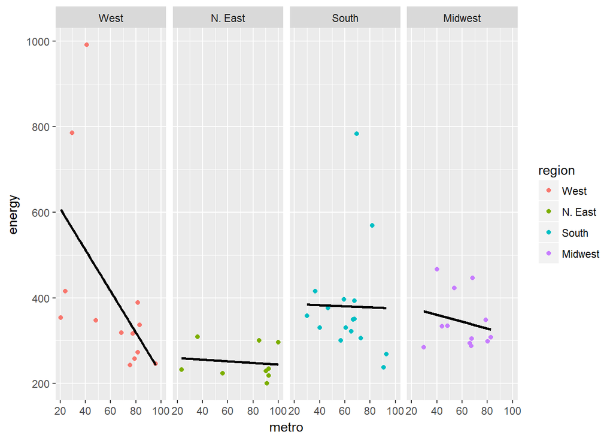

```r
ggplot(states.data[which(!is.na(states.data$region)),], aes(x=metro, y=energy, col=region)) +
  geom_point() + facet_grid(. ~ region) + stat_smooth(method = "lm", se = FALSE, col="black")
```

Seeing if region improves the model:

```r
energyReg4 <- lm(energy ~ metro + region, data = states.data)
summary(energyReg4)
```

```
##
## Call:
## lm(formula = energy ~ metro + region, data = states.data)
##
## Residuals:
##     Min      1Q  Median      3Q     Max
## -136.77  -72.21  -30.92   17.72  545.48
##
## Coefficients:
##                Estimate Std. Error t value Pr(>|t|)
## (Intercept)    524.0654    68.0373   7.703 9.37e-10 ***
## metro           -1.9112     0.9121  -2.095   0.0418 *
## regionN. East -133.3984    60.2136  -2.215   0.0318 *
## regionSouth    -24.0846    50.9769  -0.472   0.6389
## regionMidwest  -64.1673    54.6618  -1.174   0.2466
## ---
## Signif. codes:  0 '***' 0.001 '**' 0.01 '*' 0.05 '.' 0.1 ' ' 1
##
## Residual standard error: 136.5 on 45 degrees of freedom
##   (1 observation deleted due to missingness)
## Multiple R-squared:  0.2135, Adjusted R-squared:  0.1435
## F-statistic: 3.053 on 4 and 45 DF,  p-value: 0.02615
```

The R<sup>2</sup> and adjusted R<sup>2</sup> both go up although two of the regions are not significant predictors. Adding other variables does not improve on this model.